# Regression Analysis on NBA Threes

Brandon Chan, Brayden Van De Wynckel

2024-11-13

## Index

| Order | Item |
| --- | --- |
| 1 | Objective |
| 2 | Data Description |
| 3 | Testing the Claim that Players Attempts More Threes |
| 4 | Plotting Changes in 3-Pointers Made |
| 5 | Stat Selection to Predict Threes Attempted |
| 6 | Selecting the Best 5 Variables |
| 7 | Model with the 5 Best Predictors |
| 8 | Analyzing the Model on the Train Set |
| 9 | ANOVA Table and F-test |
| 10 | Analyzing the Model Predictions on the Test Set |
| 11 | Is Defense Impacting the Number of 3 Point Shots Attempted? |
| 12 | 3PA Vs. Box-Score Defensive Stats |
| 13 | Defense Model |
| 14 | Box-Cox Transformation |
| 15 | Cook’s Distance |
| 16 | The Adjusted Defense Model |
| 17 | Rebounding and Threes Attempted |
| 18 | Conclusions |

## 1. Objective

Many older NBA fans like to make claims about how the league was different back in their day. They often criticize today’s game for the high frequency of threes attempted. Many speculate why this is the case, but clear explanations are not often provided. The aim of this analysis is to see how the number of threes attempted has changed over the years, and why these changes have taken place.

## 2. Data Description

The data is from basketballreference.com and includes all seasons in NBA history. This particular dataset includes many common stats (ex. points, offensive rating), taken as the league average of per-game stats of **teams** for a given season. For example the PTS stat in the 2023-24 season represents that average points per game scored by a team in a single game.

|  | Season | Age | Ht | Wt | G | MP | FG | FGA | 3P | 3PA | FT | FTA | ORB | DRB | TRB | AST | STL | BLK | TOV | PF | PTS | FG% | 3P% | FT% | Pace | eFG% | TOV% | ORB% | FT/FGA | … |
| --- | --- | --- | --- | --- | --- | --- | --- | --- | --- | --- | --- | --- | --- | --- | --- | --- | --- | --- | --- | --- | --- | --- | --- | --- | --- | --- | --- | --- | --- | --- |
| 1 | 2023-24 | 26.4 | 6-7 | 216 | 1230 | 241.4 | 42.2 | 88.9 | 12.8 | 35.1 | 17 | 21.7 | 10.6 | 33 | 43.5 | 26.7 | 7.5 | 5.1 | 13.6 | 18.7 | 114.2 | 0.474 | 0.366 | 0.784 | 98.5 | 0.547 | 12.1 | 24.2 | 0.192 | … |
| 2 | 2022-23 | 26.1 | 6-6 | 216 | 1230 | 241.8 | 42 | 88.3 | 12.3 | 34.2 | 18.4 | 23.5 | 10.4 | 33 | 43.4 | 25.3 | 7.3 | 4.7 | 14.1 | 20 | 114.7 | 0.475 | 0.361 | 0.782 | 99.2 | 0.545 | 12.5 | 24 | 0.208 | … |
| 3 | 2021-22 | 26.1 | 6-6 | 215 | 1230 | 241.4 | 40.6 | 88.1 | 12.4 | 35.2 | 16.9 | 21.9 | 10.3 | 34.1 | 44.5 | 24.6 | 7.6 | 4.7 | 13.8 | 19.6 | 110.6 | 0.461 | 0.354 | 0.775 | 98.2 | 0.532 | 12.3 | 23.2 | 0.192 | … |
| 4 | 2020-21 | 26.1 | 6-6 | 217 | 1080 | 241.4 | 41.2 | 88.4 | 12.7 | 34.6 | 17 | 21.8 | 9.8 | 34.5 | 44.3 | 24.8 | 7.6 | 4.9 | 13.8 | 19.3 | 112.1 | 0.466 | 0.367 | 0.778 | 99.2 | 0.538 | 12.4 | 22.2 | 0.192 | … |
| 5 | 2019-20 | 26.1 | 6-6 | 218 | 1059 | 241.8 | 40.9 | 88.8 | 12.2 | 34.1 | 17.9 | 23.1 | 10.1 | 34.8 | 44.8 | 24.4 | 7.6 | 4.9 | 14.5 | 20.8 | 111.8 | 0.46 | 0.358 | 0.773 | 100.3 | 0.529 | 12.8 | 22.5 | 0.201 | … |
| 6 | 2018-19 | 26.3 | 6-6 | 219 | 1230 | 241.6 | 41.1 | 89.2 | 11.4 | 32 | 17.7 | 23.1 | 10.3 | 34.8 | 45.2 | 24.6 | 7.6 | 5 | 14.1 | 20.9 | 111.2 | 0.461 | 0.355 | 0.766 | 100 | 0.524 | 12.4 | 22.9 | 0.198 | … |
| 7 | 2017-18 | 26.4 | 6-7 | 220 | 1230 | 241.4 | 39.6 | 86.1 | 10.5 | 29 | 16.6 | 21.7 | 9.7 | 33.8 | 43.5 | 23.2 | 7.7 | 4.8 | 14.3 | 19.9 | 106.3 | 0.46 | 0.362 | 0.767 | 97.3 | 0.521 | 13 | 22.3 | 0.193 | … |
| 8 | 2016-17 | 26.6 | 6-7 | 221 | 1230 | 241.6 | 39 | 85.4 | 9.7 | 27 | 17.8 | 23.1 | 10.1 | 33.4 | 43.5 | 22.6 | 7.7 | 4.7 | 14 | 19.9 | 105.6 | 0.457 | 0.358 | 0.772 | 96.4 | 0.514 | 12.7 | 23.3 | 0.209 | … |
| 9 | 2015-16 | 26.7 | 6-7 | 222 | 1230 | 241.8 | 38.2 | 84.6 | 8.5 | 24.1 | 17.7 | 23.4 | 10.4 | 33.3 | 43.8 | 22.3 | 7.8 | 5 | 14.4 | 20.3 | 102.7 | 0.452 | 0.354 | 0.757 | 95.8 | 0.502 | 13.2 | 23.8 | 0.209 | … |
| 10 | 2014-15 | 26.7 | 6-7 | 223 | 1230 | 242 | 37.5 | 83.6 | 7.8 | 22.4 | 17.1 | 22.8 | 10.9 | 32.4 | 43.3 | 22 | 7.7 | 4.8 | 14.4 | 20.2 | 100 | 0.449 | 0.35 | 0.75 | 93.9 | 0.496 | 13.3 | 25.1 | 0.205 | … |

[output cut: 64 more lines]

## 3. Testing the Claim that Players Attempts More Threes

We are going to start by evaluating the claim that players shoot more threes in today’s game than in past decades. This can be expressed more formally with a hypothesis test.

Claim: Players are shooting more threes in recent times than in the past. We will take the mean number of threes attempted in the 2020’s and compare it to the mean number of threes in the 1990’s as samples, and treat all decades with the three point line existed as the population.

$H_0$: $M_{2020s}$ = ($M_{1990s}$

$H_A$: $M_{2020s}$ > ($M_{1990s}$

$$t_{obs} = \frac{(M_{2020s} -
M_{1990s})-0)}{s_p(\frac{1}{n1}+ \frac{1}{n2})}$$

$$t_{obs} = 10.98176$$

At 95% significance: $t_{0.05, 28} = 2.131847$
$$t_{obs} > t_{\alpha,
n1+n2-2}$$
So we reject the null hypothesis: Players do shoot more threes in the current decade than in the past.

| Decade | Mean3s |
| --- | --- |
| 20’s | 34.64 |
| 10’s | 23.05 |
| 00’s | 15.66 |
| 90’s | 11.42 |
| 80’s | 3.45 |

## 4. Plotting Changes in 3-Pointers Made

The evidence strongly suggests that players take more 3s than in the past. We verify this with a visualization:

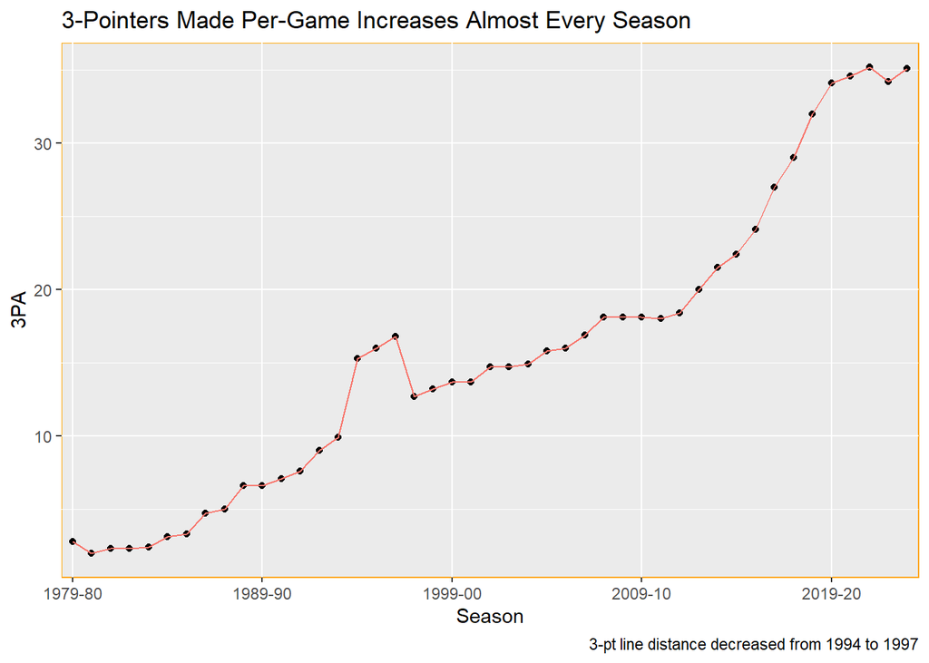

Disregarding the period when the three point line was moved, players take more threes in almost every season since the three point line was added in 1979. This leads to the question; why are players taking more threes? We will attempt to solve this question by finding what stats are contributing to changes in threes made.

## 5. Stat Selection to Predict Threes Attempted

The following variables/stats will be removed due to linear dependencies or irrelevance to the model: Season, Ht, 3P, 3P%, FG, FGA, FG%, FT/FGA, eFG%, TS%.

The best stats to predict 3PA will be selected using backwards elimination and BIC (Bayesian Information Criterion).

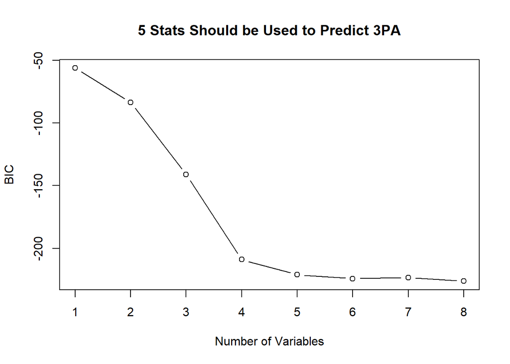

## 6. Selecting the Best 5 Predictors

Based on the variable selection process, the following 5 statistics were evaluated to be the most important for predicting the number of threes attempted by a team in a game: TRB (total rebounds), STL (steals), TOV (turnovers), PTS (points), ORB% (offensive rebound percentage).

## 7. Model with the 5 Best Predictors

The fitted model was fitted using least-squares linear regression.

$$\widehat{3PA} = -465.2109 + 4.1175TRB +
2.1830STL + 5.0996TOV + 2.6476PTS -2.9867ORB\%$$

The linear model was trained on the train set after splitting the data into 70% training data and 30% testing data.

## 8. Analyzing the Model on the Train Set

**Descriptive Statistics**

Adjusted R-squared: 0.9955

## 9. ANOVA Table and F-test

| Label | DF | SS | MS | F |
| --- | --- | --- | --- | --- |
| Regression | 5 | 3898.67 | 779.7340 | 1676.13 |
| Residual | 25 | 11.63 | 0.4652 |  |
| Total | 30 | 3910.30 | 130.3433 |  |

F-test for the significance of the regression model at significance level $\alpha=0.05$:

$$F_{obs} = \frac{MS_{reg}}{MS_{res}} =
1676.13$$

$$F_{0.05, p, n-(p+1)} = F_{0.05, 5, 25} =
2.602987$$

Clearly $F_{obs} > F_{0.05, 5, 25}$ by a significant margin. Therefore we can assume that the model predictors are significant and the coefficients are not 0.

## 10. Analyzing the Model Predictions on the Test Set

**Descriptive Statistics**

$R^2$ = 0.9931568

RMSE = 0.7669981

Here are some examples of predicted threes attempted compared to the actual volume attempted during NBA seasons:

| True3PA | Predicted3PA |
| --- | --- |
| 27.0 | 30.89667 |
| 21.5 | 22.89243 |
| 18.4 | 18.02063 |
| 18.1 | 21.41419 |
| 16.0 | 17.27590 |
| 15.8 | 14.31611 |

## 11. Is Defense Impacting the Number of 3 Point Shots Attempted?

Based on the variable selection process in the last step, defensive stats appear to be effective in predicting threes attempted. Could this due to defensive strategies that are limiting drives to the basket and forcing more threes? In order to determine if this is true, we will regress various common defensive stats to see if better defense leads to more 3 point attempts taken.

## 12. 3PA Vs. Box-Score Defensive Stats

We start by checking the relationship between threes attempted and defensive box-score stats.

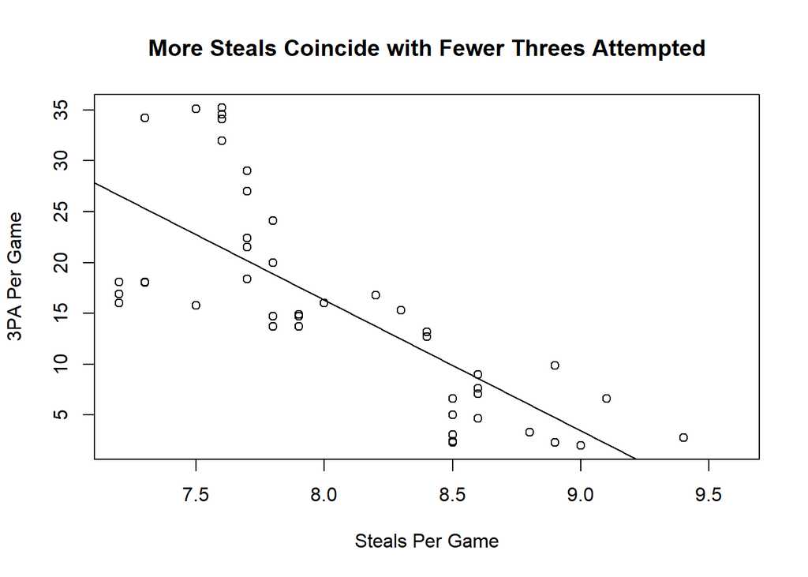

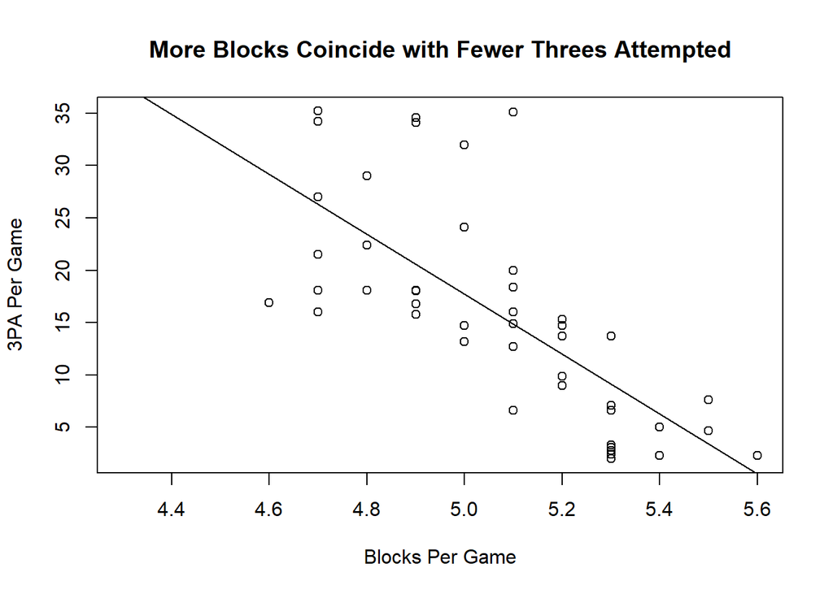

## 13. Defense Model

There clearly appears to be some relationship between defensive stats and the number of threes attempted. We wanted to analyze this relationship further, so we formed a model with defensive stats using steals, turnovers, blocks, and defensive rebounds are predictors for three attempted. The model formula is a follows:

$$\widehat{3PA} = 6.5024 + 0.6960STL -
3.08078TOV - 6.0463BLK + 2.6883DRB$$

The model has an adjusted $R^2$ value of 0.8961. It’s not bad, but it might improve with a couple of adjustments.

## 14. Box-Cox Transformation

The first adjustment applied is the Box-Cox transformation. Despite using the Box-Cox transformation on the model with the optimal lambda value of 0.55, the model’s adjusted $R^2$ stayed the same.

$$\widehat{3PA} = 10.0878 + 1.2760STL -
5.6480TOV - 11.0849BLK + 4.9286DRB$$

## 15. Cook’s Distance

Another adjustment to potentially improve the model is to check for influential observations that are disproportionately affecting the model. This is checked using Cook’s distance.

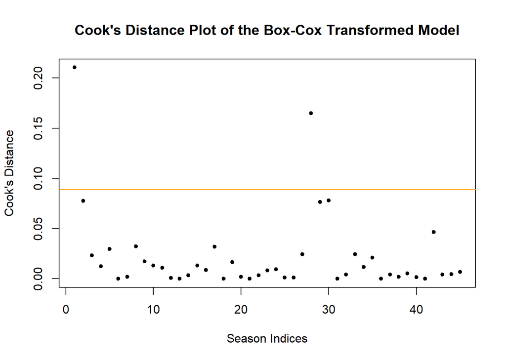

There are a few influential observations, and the first one is incredibly apparent. The influential observations will be removed to attempt to obtain better results.

## 16. The Adjusted Defense Model

Model formed using defensive stats after applying the Box-Cox transformation and removing influential observations:
$$\widehat{3PA} = -43.8348 + 2.2741STL -
3.7727TOV - 12.9361BLK + 5.6905DRB$$

After removing influential observations, adjusted $R^2$ increases to 0.9264.

Based on the model, defensive metrics are effective in predicting the number of threes attempted. It appears that as defensive stats improve, 3 point shot attempts fall. This may be because teams are not comfortable taking deep shots when their players are guarded closely and are being disrupted by defensive players.

## 17. Rebounding and Threes Attempted

The relationship between defensive rebounding and threes attempted could just be attributed to a team’s positioning in a spaced-out offense. When a team is playing a 5-out offense with all offensive players looking to shoot threes, the defence is more likely to recover missed shots since they are closer to the rim.

We verify this by regressing 3 point shot attempts against offensive and defensive rebounds.

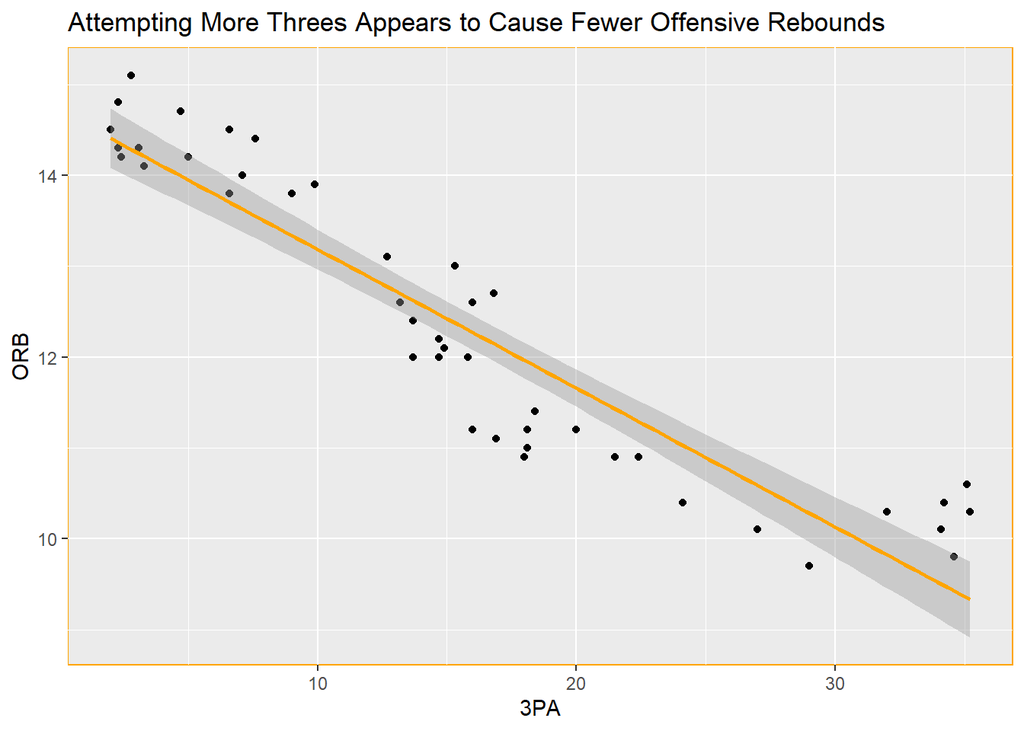

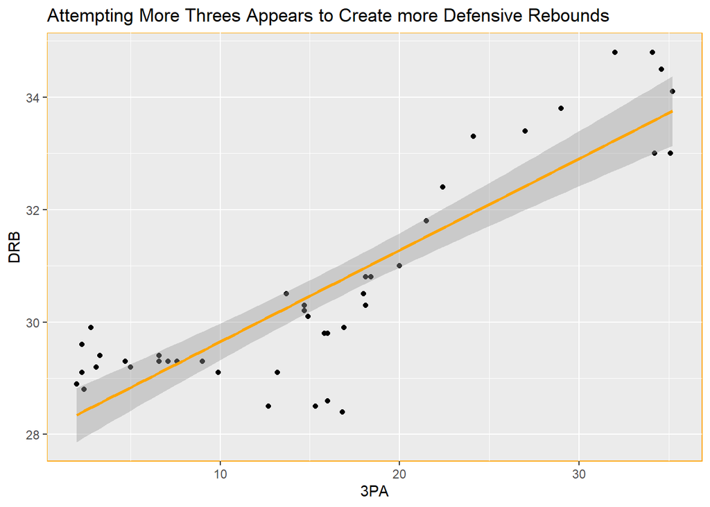

## 18. Conclusions

The number of threes attempts has been steadily increasing in almost every season since the inception of the three point line in 1979. We were able to determine several reason why this may be the case, including changes in related statistics and the impact of defense. Using what we discovered in the analysis we can now have a clear hypothesis for why the number of threes has skyrocketed throughout the decades:

Attempting more threes makes guarding more difficult for defenses, leading to lower block and steal numbers. While the number of offensive rebounds decreases when having a spaced-out offense, scoring still increases when attempting more threes. Attempting more threes also appears to be less risky and lead to fewer turnovers, which can be costly for teams. To summarise, it appears that shooting more threes makes offenses better and defenses worse, which provides incentive for teams to take more of them.